# DATASCI 151 - Introduction to Statistical Computing II

Lecture 03 - Maths Operations, Arrays, and Boolean Logic

Danilo Freire

danilo.freire@emory.edu

Department of Data and Decision Sciences  
Emory University

# Welcome to another lecture! 😊

## Today’s agenda

### Introducing NumPy, `random`, and Boolean logic

- [NumPy](https://numpy.org) (short for Numerical Python) is a library for working with arrays
- An [array](https://numpy.org/doc/stable/user/absolute_beginners.html) is a collection of numbers arranged in a regular grid
- 1D arrays are vectors, 2D arrays are matrices, higher-dimensional ones are tensors
- Think of a NumPy array as a “super-powered list of numbers”
- NumPy is the backbone of `pandas`, `scikit-learn`, and many other Python libraries
- Next, we will see the `random` module, which generates random numbers
- Finally, [Boolean logic](https://en.wikipedia.org/wiki/Boolean_data_type): how Python works with `True` and `False`

[figure not shown]

# Let’s get started! 🚀

## Importing NumPy and Matplotlib

- As usual, we start by importing the libraries we will use
- NumPy has several functions
- For instance, $\ln(x), e^x, \sin(x), \cos(x), \sqrt{x}$
- Remember that exponentiation in Python is done using `**`, not `^`
- You can check a list of NumPy functions [here](https://numpy.org/doc/stable/reference/routines.math.html) (there are many!)

```python
# Importing packages
import numpy as np
import matplotlib.pyplot as plt

# log(x): logarithm with base "e"
# exp(x): Euler constant power of "x"
# sin(x): sine of x
# cos(x): cosine of x
# We're substituting x = 1
print(np.log(1))
print(np.exp(1))
print(np.sin(1))
print(np.cos(1))
print(np.sqrt(1))
```

```
0.0
2.718281828459045
0.8414709848078965
0.5403023058681398
1.0
```

## Try it yourself! 🧠

- Create a new variable, $x = 5$
- Compute $\pi x^2$
- Compute $\frac{1}{\sqrt{2\pi}}e^{-x^2/2}$
  - This is the [probability density function of the standard normal distribution](https://en.wikipedia.org/wiki/Normal_distribution) (don’t worry if you don’t know what it is yet! 🤓)
- Don’t forget how to exponentiate in Python 😉

```python
x = 10
x ** 5

# Not x^5
```

```
100000
```

- Appendix 01

# Vector arrays with NumPy 📊

## Creating arrays from lists

- NumPy arrays are created using the `np.array()` function
- We can create arrays from lists
- We can also create arrays with a sequence of numbers using `np.arange()`
- We can create arrays with zeros or ones using `np.zeros()` and `np.ones()`
- And we’re going to learn all of this in this course! 🤓

## Creating arrays from lists

- Create an array from a list
- $a = \begin{pmatrix} 1 \\ 2 \\ 3 \end{pmatrix}$
- $b = \begin{pmatrix} 0 \\ 1 \\ 0\end{pmatrix}$
- $c = \begin{pmatrix} 10 \\ 100 \\ 1000 \\ 2000 \\ 5000 \end{pmatrix}$
- $d = \begin{pmatrix} 4 \\ 2 \end{pmatrix}$

```python
vec_a  = np.array([1,2,3])
vec_b  = np.array([0,1,0])
vec_c  = np.array([10,100,1000,2000,5000])
vec_d  = np.array([4,2])
```

## Accessing an element of an array

- We can access elements of an array using square brackets `[]`
- Remember that Python is zero-indexed, which means that the first element is accessed with index 0, the second with index 1, and so on
- Access the first and the third element of $a$

```python
print(vec_a)
print(vec_a[0])
print(vec_a[2])
```

```
[1 2 3]
1
3
```

## Operations with a single array and a scalar

- We can perform operations with a single array and a scalar
- For instance, we can add or multiply a scalar to an array
- Add 2 to each element of $a$
- $a + 2 = \begin{pmatrix} a_1 + 2 \\ a_2 + 2 \\ a_3 + 2 \end{pmatrix}$

```python
# Print the original array
print(vec_a)

# Adding 2 to each element of a
print(vec_a + 2)
```

```
[1 2 3]
[3 4 5]
```

- A scalar refers to either an int or float
- We can do many common operations, such as:

```python
print(vec_a * 2)
print(vec_a / 2)
print(vec_a + 2)
print(vec_a ** 2)
```

```
[2 4 6]
[0.5 1.  1.5]
[3 4 5]
[1 4 9]
```

## Element-by-element addition between two arrays of the same size

$a + b = \begin{pmatrix} a_1 \\ a_2 \\ a_3 \end{pmatrix} +$ $\begin{pmatrix} b_1 \\ b_2 \\ b_3 \end{pmatrix} =$ $\begin{pmatrix} a_1 + b_1 \\ a_2 + b_2 \\ a_3 + b_3 \end{pmatrix}$

```python
print(vec_a)
print(vec_b)

# When you add two arrays of the same size,
# Python adds the individual elements in each position
print(vec_a + vec_b)
```

```
[1 2 3]
[0 1 0]
[1 3 3]
```

## Element-by-element multiplication between two arrays of the same size

$a * b = \begin{pmatrix} a_1 * b_1 \\ a_2 * b_2 \\ a_3 * b_3 \end{pmatrix}$

```python
print(vec_a)
print(vec_b)

# When you multiply two arrays of the same size,
# Python multiplies the individual elements in each position
print(vec_a * vec_b)

# We can do other similar element-by-element operations
# such as subtraction, and division.
print(vec_a - vec_b)
# Dividing by 0 gives inf (and a warning)
print(vec_a / vec_b)
```

```
[1 2 3]
[0 1 0]
[0 2 0]
[1 1 3]
[inf  2. inf]
```

# Summary statistics 📊

## Summary statistics of an array

- NumPy provides several functions to compute summary statistics of an array
- For instance, we can compute the mean, median, standard deviation, variance, minimum, and maximum
- We can also compute the sum, product, and cumulative sum of the elements in an array

```python
print(np.mean(vec_a))
print(np.std(vec_a))
print(np.min(vec_a))
print(np.median(vec_a))
print(np.max(vec_a))
print(np.sum(vec_a))
print(np.prod(vec_a))
print(np.cumsum(vec_a))
```

```
2.0
0.816496580927726
1
2.0
3
6
6
[1 3 6]
```

## Try it yourself! 🧠

- Compute the mean of:

$e = \begin{pmatrix} 10 \\ 8 \\ 15 \\ 0 \\ 24 \end{pmatrix}$

- Appendix 02

## Common pitfall

### Make sure that the arrays are of the same size!

```python
print(vec_a)
print(vec_c)

# Print the shape of the arrays
print(vec_a.shape)
print(vec_c.shape)
```

```
[1 2 3]
[  10  100 1000 2000 5000]
(3,)
(5,)
```

```python
# When you add two arrays of different sizes,
# Python will raise an error
print(vec_a + vec_c)
```

```
Traceback (most recent call last):
  File "<python-input-10>", line 1, in <module>
    print(vec_a + vec_c)
          ~~~~~~^~~~~~~
ValueError: operands could not be broadcast together with shapes (3,) (5,)
>>>
```

# Questions?

# Random numbers with Python 🎲

## Generating random numbers

- Why randomness?
  - Simulate different scenarios: high risk or low risk
  - Study properties of a complex system and/or estimator
  - In medicine, randomly assign subjects to treatment or control
  - In finance, simulate stock prices
  - In sports, simulate outcomes of games, etc
- This code creates a vector of random variables generated from a normal distribution
- It has the mean `loc` (location) and standard deviation `scale`
- The number of distinct variables is `size`
- More information about the `normal` function [here](https://numpy.org/doc/stable/reference/random/generated/numpy.random.normal.html)

```python
# Generate 10 random variables
# from a normal distribution
# with mean = 0 and sd = 1
random_var_a = np.random.normal(loc=0, scale=1, size=10)
print(random_var_a)
```

```
[-0.2837879  -0.80461618 -0.21886579 -3.1305208  -1.6733438   0.63639163
  0.20603458 -1.44479918  0.50057824 -0.5613351 ]
```

## Random numbers differ every time!

- Avoid this problem by drawing from a “pregenerated” set!
- This is called a seed, and it is set using `np.random.seed()`
- This allows for [reproducibility](https://en.wikipedia.org/wiki/Reproducibility) of results

```python
np.random.seed(151)

random_var_b = np.random.normal(loc=0, scale=1, size=10)
print(random_var_b)
```

```
[-0.63673759  0.53155853  0.99020835 -0.6241344   1.46778078  0.40501276
  1.29817371 -2.61363271  1.35643373  1.87316055]
```

## Compute a histogram with the results

- We can use the `plt.hist()` function to compute a histogram

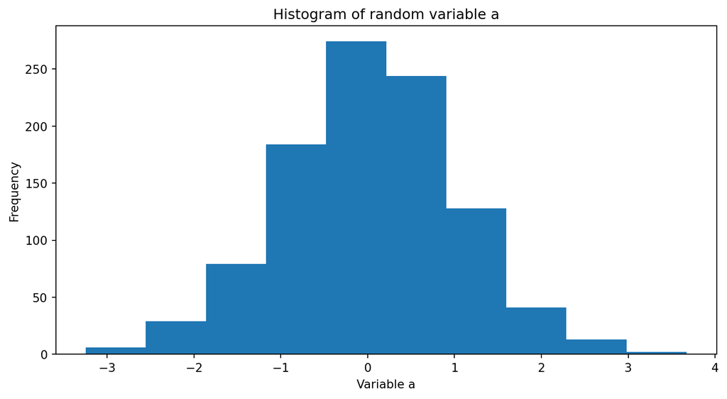

```python
# Create a histogram of the random variable
random_var_x = np.random.normal(loc=0, scale=1, size=1000)

plt.hist(random_var_x)
plt.xlabel("Variable a")
plt.ylabel("Frequency")
plt.title("Histogram of random variable a")
plt.show()
```

## Try it yourself!

- Try this again with $size = 100, 1000, 10000$ and see how the histogram changes
- Appendix 03

# Boolean logic 🧠

## Boolean logic

### A bit of history

- Named after [George Boole](https://en.wikipedia.org/wiki/George_Boole), a British mathematician and philosopher
- [Boole’s work on logic](https://en.wikipedia.org/wiki/Boolean_algebra) laid the foundation for modern computer science
- Boolean logic is a branch of algebra that deals with [true and false values](https://en.wikipedia.org/wiki/Boolean_data_type)
- It is useful for computer programming because it is based on [binary](https://en.wikipedia.org/wiki/Binary_number) values
- In Python, Boolean values are `True` and `False`
- We use them to make decisions in our code

[figure not shown]

# Testing expressions with text 🐍

## True and False values

- We can test whether two values are equal using the == operator (two equal signs)
- For example, 5 == 5 returns `True`
- We can also test whether two values are not equal using the != operator (exclamation mark followed by an equal sign)
- Let’s see how this works in Python
- First, let’s load the `matplotlib` and `numpy` libraries

```python
import matplotlib.pyplot as plt
import numpy as np

# You can compare two strings by using a double "equal sign"
# This can be useful if you're trying to evaluate whether data was entered correctly

"Is this the real life?" == "is this just fantasy?"
```

```
False
```

Note: the order of the characters matters!

```python
"ab" == "ba"
```

```
False
```

## True and False values

- Equality of strings is most useful when you’re comparing an unknown variable to a benchmark
- Below, try switching the value of `any_questions`

```python
any_questions = "no"
print(any_questions == "no")
```

```
True
```

```python
any_questions = "yes"
print(any_questions == "no")
```

```
False
```

## Test for the presence of keywords in a sentence (`in` operator)

- We can test whether a keyword is present in a sentence or a list using the `in` operator
- For example, `"apple" in "I like apples"` returns `True`
- Let’s see how this works in Python

```python
"apple" in "I like apples"
```

```
True
```

```python
keyword = "economic"
sentence = "The Federal Reserve makes forecasts about many economic outcomes"

keyword in sentence

# Try changing the keyword!
```

```
True
```

- Now, let’s test whether a keyword is present in a list

```python
current_month = "September"
list_summer_months = ["June","July","August"]

print(current_month in list_summer_months)
print('June' in list_summer_months)
```

```
False
True
```

# Testing expressions with numbers 🐍

## Testing expressions with numbers

- Tests with numbers
  - Strictly less than (<), less than or equal (<=)
  - Equal (==)
  - Strictly more than (>), greater than or equal to (>=)
- Let’s see how this works in Python

```python
x = 5

print(x < 5)
print(x <= 5)
print(x == 5)
print(x >= 5)
print(x > 5)
```

```
False
True
True
True
False
```

## Validate a data type

- We can test whether a variable is of a certain data type using the `isinstance()` function
- For example, `isinstance(5, int)` returns `True`
- Other data types include `float`, `str`, `list`, `tuple`, `dict`, `set`, `bool`

```python
y = 10

print(isinstance(y,int))
print(isinstance(y,float))
print(isinstance(y,str))
```

```
True
False
False
```

## Equality of vectors

- We can test whether two vectors are equal using the same == operator
- For lists, `[1,2,3] == [1,2,3]` returns a single `True`
- For NumPy arrays, the comparison is done element-wise: one `True`/`False` per position (use `np.array_equal()` to compare whole arrays)

```python
vec_a = np.array([1,2,3])
vec_b = np.array([1,2,4])

vec_a == vec_b
```

```
array([ True,  True, False])
```

## Try it yourself! 🧠

- Define $x= -1$. Check whether $x^2 + 2x + 1 = 0$ is true
  - Please remember that $x^2$ is written as `x**2` in Python
  - Please note the difference between `==` and `=`
- Appendix 04

# Testing multiple conditions 🐍

## Testing multiple conditions

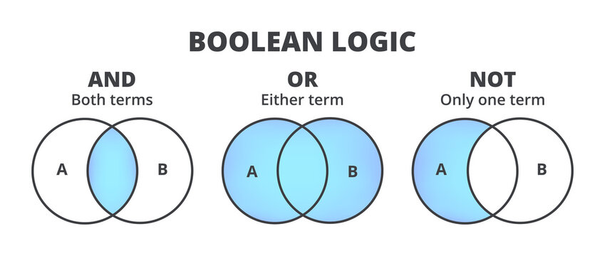

- We can test multiple conditions using the `and` and `or` operators
- The `and` operator returns `True` if both conditions are `True`
- The `or` operator returns `True` if at least one condition is `True`

## `not`: the negation operator

- We can negate a condition using the `not` operator
- The `not` operator returns `True` if the condition is `False` and vice versa
  - Yes, it’s a bit confusing at first, but it’s intuitive once you see it in action
- For instance, imagine that you want to know whether someone can vote in the US
  - Here let’s assume the person is a national and we only care about age
  - The person can vote if they are at least 18 years old

```python
age = 22

# Can this person legally vote in the US?
not (age < 18)
```

```
True
```

- The `not` operator can be separated by a space and parentheses are not necessary
- But parentheses can be helpful to organise your code logically

```python
not age < 18
```

```
True
```

## Condition A and B need to be satisfied: `and` operator

- We can combine two conditions with the `and` operator
- The `and` operator returns `True` only if both conditions are `True`
- For example, `(5 > 3) and (5 < 10)` returns `True`

```python
# We use the `and` keyword to combine two conditions
age = 31

# Is this age between 20 and 30 (including these ages)?
(age >= 20) and (age <= 30)
```

```
False
```

## Condition A or B needs to be satisfied: `or` operator

- To test whether at least one condition is `True`, we use the `or` operator
- For example, `(5 > 3) or (5 > 10)` returns `True`

```python
# We use the `or` keyword to combine two conditions
age = 31

# Is this age at least 20 or at most 30?
(age >= 20) or (age <= 30)
```

```
True
```

```python
# Another example
student_status = "freshman"

# Is the student in the first two years of undergrad?
(student_status == "freshman") or (student_status == "sophomore")
```

```
True
```

## Looking ahead: `and` and `or` vs `&` and `|` 💡

- For single values (one comparison at a time), use `and`, `or`, and `not`
- For NumPy arrays (a whole list of values), use `&`, `|`, and `~`
  - These check each element separately and return one answer per element

```python
# Single value: one True/False answer
age = 25
print((age >= 20) and (age <= 30))

# Array of values: one True/False per element
ages = np.array([15, 25, 35])
print((ages >= 20) & (ages <= 30))
```

```
True
[False  True False]
```

- We will use this later in the course, when we filter data 🚀

## Try it yourself! 🚀

- Now, let’s test whether you can identify the correct expression
- Write code that checks the following conditions:
  - Whether age (31) is strictly less than 20, or greater than 30
  - Not in the age range 25-27
- Appendix 05

# And that’s all for today! 🥳

# Thank you very much and see you next time! 🙏

## Appendix 01

### Mathematical functions in NumPy

- Create a new variable, $x = 5$
- Compute $\pi x^2$
- Compute $\frac{1}{\sqrt{2\pi}}e^{-x^2/2}$

```python
x = 5
print(np.pi * x ** 2)
print((1 / np.sqrt(2 * np.pi)) * np.exp(-x ** 2 / 2))
```

```
78.53981633974483
1.4867195147342977e-06
```

Back to exercise

## Appendix 02

### Summary statistics of an array

- Compute the mean of
- $e = \begin{pmatrix} 10 \\ 8 \\ 15 \\ 0 \\ 24 \end{pmatrix}$

```python
vec_e = np.array([10, 8, 15, 0, 24])
print(np.mean(vec_e))
```

```
11.4
```

Back to exercise

## Appendix 03

### Histogram with different sample sizes

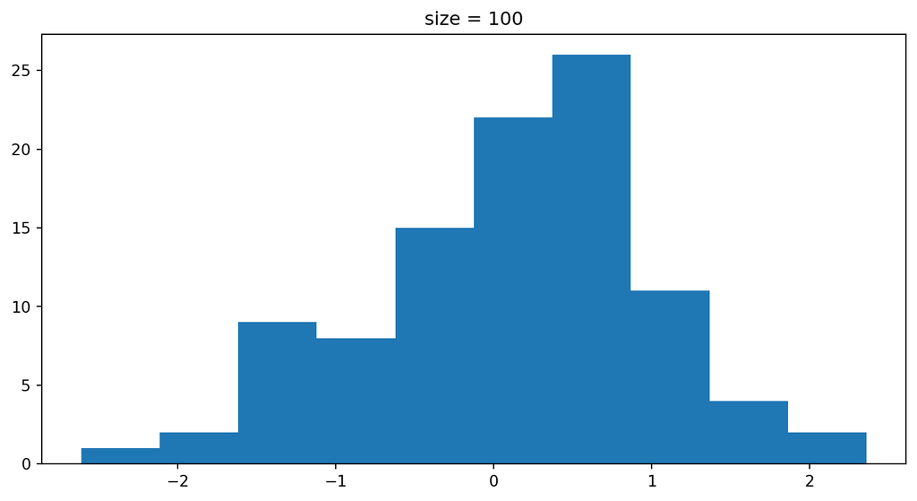

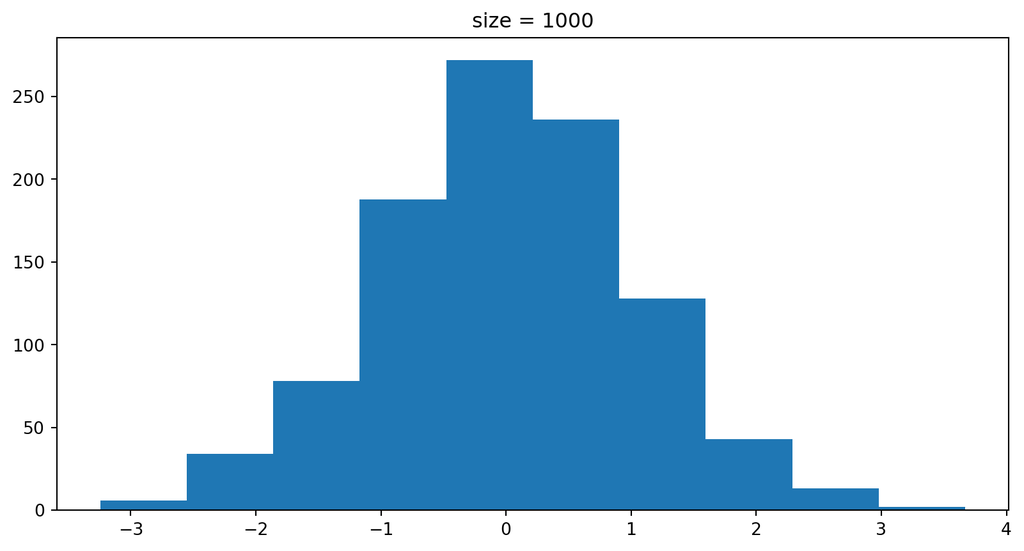

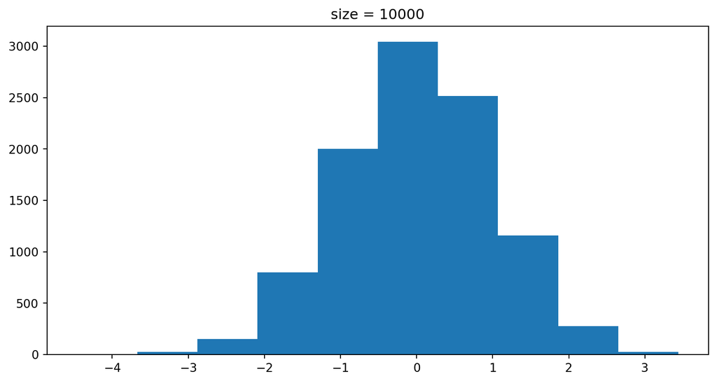

```python
np.random.seed(151)

plt.hist(np.random.normal(loc=0, scale=1, size=100))
plt.title("size = 100")
plt.show()

plt.hist(np.random.normal(loc=0, scale=1, size=1000))
plt.title("size = 1000")
plt.show()

plt.hist(np.random.normal(loc=0, scale=1, size=10000))
plt.title("size = 10000")
plt.show()
```

- As `size` grows, the histogram becomes smoother and looks more like the bell curve of the normal distribution

Back to exercise

## Appendix 04

- Whether $x = -1$ is a solution to the equation $x^2 + 2x + 1 = 0$
- Please remember that $x^2$ is written as `x**2` in Python

```python
x = -1
print(x ** 2 + 2 * x + 1 == 0)
```

```
True
```

Back to exercise

## Appendix 05

- Whether age (`age = 31`) is strictly less than 20, or greater than 30
- Not in the age range 25-27

```python
age = 31

(age < 20) or (age > 30)
```

```
True
```

```python
(age < 25) or (age > 27)
```

```
True
```

The second answer uses `or` because no single age can satisfy both conditions at once: [less than 25 and greater than 27 has no solution](https://en.wikipedia.org/wiki/Empty_set). We want to know if either is true, since that means the age falls outside the 25-27 range

Back to exercise